# GEOG891_Lab1_Yoo

## Load Packages

```r
library(tidyverse)
library(sp)
library(ggplot2)
library(hrbrthemes)
```

## Load Data

```r
p.counties <- "../data/CBW/County_Boundaries.shp"
p.stations <- "../data/CBW/Non-Tidal_Water_Quality_Monitoring_Stations_in_the_Chesapeake_Bay.shp"
d.counties <- sf::read_sf(p.counties)
d.stations <- sf::read_sf(p.stations)
glimpse(d.counties)
```

```
## Rows: 207
## Columns: 21
## $ OBJECTID   <int> 1, 2, 3, 4, 5, 6, 7, 8, 9, 10, 11, 12, 13, 14, 15, 16, 17, ~
## $ STATEFP10  <chr> "51", "51", "51", "51", "42", "42", "42", "42", "42", "42",~
## $ COUNTYFP10 <chr> "540", "510", "530", "600", "021", "001", "061", "035", "09~
## $ COUNTYNS10 <chr> "01789068", "01498415", "01498417", "01789070", "01213662",~
## $ GEOID10    <chr> "51540", "51510", "51530", "51600", "42021", "42001", "4206~
## $ NAME10     <chr> "Charlottesville", "Alexandria", "Buena Vista", "Fairfax", ~
## $ NAMELSAD10 <chr> "Charlottesville city", "Alexandria city", "Buena Vista cit~
## $ LSAD10     <chr> "25", "25", "25", "25", "06", "06", "06", "06", "06", "06",~
## $ CLASSFP10  <chr> "C7", "C7", "C7", "C7", "H1", "H1", "H1", "H1", "H1", "H1",~
## $ MTFCC10    <chr> "G4020", "G4020", "G4020", "G4020", "G4020", "G4020", "G402~
## $ CSAFP10    <chr> NA, "548", NA, "548", NA, "564", NA, "558", NA, NA, NA, NA,~
## $ CBSAFP10   <chr> "16820", "47900", NA, "47900", "27780", "23900", "26500", "~
## $ METDIVFP10 <chr> NA, "47894", NA, "47894", NA, NA, NA, NA, NA, NA, NA, NA, N~
## $ FUNCSTAT10 <chr> "F", "F", "F", "F", "A", "A", "A", "A", "A", "A", "A", "A",~
## $ ALAND10    <dbl> 26517362, 38919733, 17362236, 16159465, 1782819861, 1343342~
## $ AWATER10   <dbl> 52974, 1140371, 223855, 95054, 13680552, 8081576, 37883358,~
## $ INTPTLAT10 <chr> "+38.0376579", "+38.8183429", "+37.7316634", "+38.8531833",~
## $ INTPTLON10 <chr> "-078.4853806", "-077.0820263", "-079.3563746", "-077.29902~
## $ Shape_Leng <dbl> 47968.96, 43943.77, 34310.52, 29395.95, 260532.87, 195653.0~
## $ Shape_Area <dbl> 42902561, 66086698, 28163001, 26840867, 3109865228, 2297092~
## $ geometry   <MULTIPOLYGON [°]> MULTIPOLYGON (((-78.47071 3..., MULTIPOLYGON (~
```

```r
glimpse(d.stations)
```

```
## Rows: 122
## Columns: 12
## $ OBJECTID   <int> 1, 2, 3, 4, 5, 6, 7, 8, 9, 10, 11, 12, 13, 14, 15, 16, 17, ~
## $ MAP_ID     <int> 1, 2, 3, 4, 5, 6, 7, 8, 9, 10, 11, 12, 13, 14, 15, 16, 17, ~
## $ USGS_STATI <int> 1487000, 1488500, 1491000, 1491500, 1495000, 1502500, 15030~
## $ STATION_NA <chr> "NANTICOKE RIVER NEAR BRIDGEVILLE, DE", "MARSHYHOPE CREEK N~
## $ MAJOR_WATE <chr> "Eastern Shore", "Eastern Shore", "Eastern Shore", "Eastern~
## $ Drainage_A <dbl> 75.39997, 46.79998, 112.99995, 85.19996, 51.59998, 519.9997~
## $ START_DATE <int> 1998, 2005, 1985, 2005, 2005, 2005, 2006, 2005, 2006, 2005,~
## $ END_DATE   <int> 2018, 2018, 2018, 2018, 2018, 2018, 2018, 2018, 2018, 2018,~
## $ Lat        <dbl> 38.72833, 38.84969, 38.99719, 38.96681, 39.66758, 42.37778,~
## $ Long       <dbl> -75.56186, -75.67311, -75.78581, -75.94306, -75.82558, -75.~
## $ STAID      <chr> "01487000", "01488500", "01491000", "01491500", "01495000",~
## $ geometry   <POINT [°]> POINT (-75.56186 38.72834), POINT (-75.67311 38.8497)~
```

## Select

```r
d.counties %>% dplyr::select(GEOID10, ALAND10) %>% head()
```

```
## Simple feature collection with 6 features and 2 fields
## Geometry type: MULTIPOLYGON
## Dimension:     XY
## Bounding box:  xmin: -79.38264 ymin: 37.69574 xmax: -76.95493 ymax: 40.72605
## Geodetic CRS:  WGS 84
## # A tibble: 6 x 3
##   GEOID10    ALAND10                                                    geometry
##   <chr>        <dbl>                                          <MULTIPOLYGON [°]>
## 1 51540     26517362 (((-78.47071 38.04872, -78.47033 38.04801, -78.47009 38.04~
## 2 51510     38919733 (((-77.06247 38.79497, -77.06268 38.79504, -77.06273 38.79~
## 3 51530     17362236 (((-79.36681 37.72723, -79.36687 37.72744, -79.36704 37.72~
## 4 51600     16159465 (((-77.31427 38.86701, -77.31414 38.867, -77.31398 38.8669~
## 5 42021   1782819861 (((-79.03392 40.3165, -79.03359 40.31674, -79.0322 40.3173~
## 6 42001   1343342705 (((-77.46596 39.85977, -77.46596 39.85983, -77.46599 39.86~
```

```r
d.counties %>% dplyr::select(GEOID10:CLASSFP10) %>% head()
```

```
## Simple feature collection with 6 features and 5 fields
## Geometry type: MULTIPOLYGON
## Dimension:     XY
## Bounding box:  xmin: -79.38264 ymin: 37.69574 xmax: -76.95493 ymax: 40.72605
## Geodetic CRS:  WGS 84
## # A tibble: 6 x 6
##   GEOID10 NAME10          NAMELSAD10           LSAD10 CLASSFP10                  geometry
##   <chr>   <chr>           <chr>                <chr>  <chr>            <MULTIPOLYGON [°]>
## 1 51540   Charlottesville Charlottesville city 25     C7        (((-78.47071 38.04872, -~
## 2 51510   Alexandria      Alexandria city      25     C7        (((-77.06247 38.79497, -~
## 3 51530   Buena Vista     Buena Vista city     25     C7        (((-79.36681 37.72723, -~
## 4 51600   Fairfax         Fairfax city         25     C7        (((-77.31427 38.86701, -~
## 5 42021   Cambria         Cambria County       06     H1        (((-79.03392 40.3165, -7~
## 6 42001   Adams           Adams County         06     H1        (((-77.46596 39.85977, -~
```

```r
d.counties %>% dplyr::select(-(GEOID10:CLASSFP10)) %>% head()
```

```
## Simple feature collection with 6 features and 15 fields
## Geometry type: MULTIPOLYGON
## Dimension:     XY
## Bounding box:  xmin: -79.38264 ymin: 37.69574 xmax: -76.95493 ymax: 40.72605
## Geodetic CRS:  WGS 84
## # A tibble: 6 x 16
##   OBJECTID STATEFP10 COUNTYFP10 COUNTYNS10 MTFCC10 CSAFP10 CBSAFP10 METDIVFP10
##      <int> <chr>     <chr>      <chr>      <chr>   <chr>   <chr>    <chr>
## 1        1 51        540        01789068   G4020   <NA>    16820    <NA>
## 2        2 51        510        01498415   G4020   548     47900    47894
## 3        3 51        530        01498417   G4020   <NA>    <NA>     <NA>
## 4        4 51        600        01789070   G4020   548     47900    47894
## 5        5 42        021        01213662   G4020   <NA>    27780    <NA>
## 6        6 42        001        01213656   G4020   564     23900    <NA>
## # ... with 8 more variables: FUNCSTAT10 <chr>, ALAND10 <dbl>, AWATER10 <dbl>,
## #   INTPTLAT10 <chr>, INTPTLON10 <chr>, Shape_Leng <dbl>, Shape_Area <dbl>,
## #   geometry <MULTIPOLYGON [°]>
```

```r
d.counties %>% dplyr::select(starts_with("C"))
```

```
## Simple feature collection with 207 features and 5 fields
## Geometry type: MULTIPOLYGON
## Dimension:     XY
## Bounding box:  xmin: -81.01449 ymin: 36.55035 xmax: -74.16468 ymax: 44.09697
## Geodetic CRS:  WGS 84
## # A tibble: 207 x 6
##    COUNTYFP10 COUNTYNS10 CLASSFP10 CSAFP10 CBSAFP10                     geometry
##    <chr>      <chr>      <chr>     <chr>   <chr>              <MULTIPOLYGON [°]>
##  1 540        01789068   C7        <NA>    16820    (((-78.47071 38.04872, -78.~
##  2 510        01498415   C7        548     47900    (((-77.06247 38.79497, -77.~
##  3 530        01498417   C7        <NA>    <NA>     (((-79.36681 37.72723, -79.~
##  4 600        01789070   C7        548     47900    (((-77.31427 38.86701, -77.~
##  5 021        01213662   H1        <NA>    27780    (((-79.03392 40.3165, -79.0~
##  6 001        01213656   H1        564     23900    (((-77.46596 39.85977, -77.~
##  7 061        01213672   H1        <NA>    26500    (((-78.15023 40.17464, -78.~
##  8 035        01214721   H1        558     30820    (((-78.05358 41.27373, -78.~
##  9 093        01213681   H1        <NA>    14100    (((-76.55874 40.93904, -76.~
## 10 117        01209189   H1        <NA>    <NA>     (((-77.21965 41.99978, -77.~
## # ... with 197 more rows
```

## Group

```r
d.counties %>% group_by(STATEFP10) %>% mutate(stateLandArea = sum(ALAND10))
```

```
## Simple feature collection with 207 features and 21 fields
## Geometry type: MULTIPOLYGON
## Dimension:     XY
## Bounding box:  xmin: -81.01449 ymin: 36.55035 xmax: -74.16468 ymax: 44.09697
## Geodetic CRS:  WGS 84
## # A tibble: 207 x 22
## # Groups:   STATEFP10 [7]
##    OBJECTID STATEFP10 COUNTYFP10 COUNTYNS10 GEOID10 NAME10   NAMELSAD10   LSAD10
##  *    <int> <chr>     <chr>      <chr>      <chr>   <chr>    <chr>        <chr>
##  1        1 51        540        01789068   51540   Charlot~ Charlottesv~ 25
##  2        2 51        510        01498415   51510   Alexand~ Alexandria ~ 25
##  3        3 51        530        01498417   51530   Buena V~ Buena Vista~ 25
##  4        4 51        600        01789070   51600   Fairfax  Fairfax city 25
##  5        5 42        021        01213662   42021   Cambria  Cambria Cou~ 06
##  6        6 42        001        01213656   42001   Adams    Adams County 06
##  7        7 42        061        01213672   42061   Hunting~ Huntingdon ~ 06
##  8        8 42        035        01214721   42035   Clinton  Clinton Cou~ 06
##  9        9 42        093        01213681   42093   Montour  Montour Cou~ 06
## 10       10 42        117        01209189   42117   Tioga    Tioga County 06
## # ... with 197 more rows, and 14 more variables: CLASSFP10 <chr>,
## #   MTFCC10 <chr>, CSAFP10 <chr>, CBSAFP10 <chr>, METDIVFP10 <chr>,
## #   FUNCSTAT10 <chr>, ALAND10 <dbl>, AWATER10 <dbl>, INTPTLAT10 <chr>,
## #   INTPTLON10 <chr>, Shape_Leng <dbl>, Shape_Area <dbl>,
## #   geometry <MULTIPOLYGON [°]>, stateLandArea <dbl>
```

```r
d.counties %>% as_tibble() %>% dplyr::select(-geometry) %>% group_by(STATEFP10) %>% summarise(stateLandArea = sum(ALAND10))
```

```
## # A tibble: 7 x 2
##   STATEFP10 stateLandArea
##   <chr>             <dbl>
## 1 10           5046703785
## 2 11            158114680
## 3 24          25141638381
## 4 36          40599407643
## 5 42          78174288199
## 6 51          69471293533
## 7 54          20781223859
```

## Plots

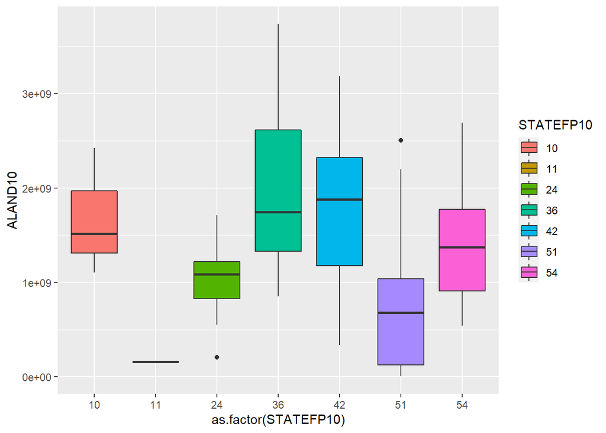

```r
d.counties %>% ggplot(., aes(x = as.factor(STATEFP10), y = ALAND10)) + geom_boxplot(aes(fill = STATEFP10))
```

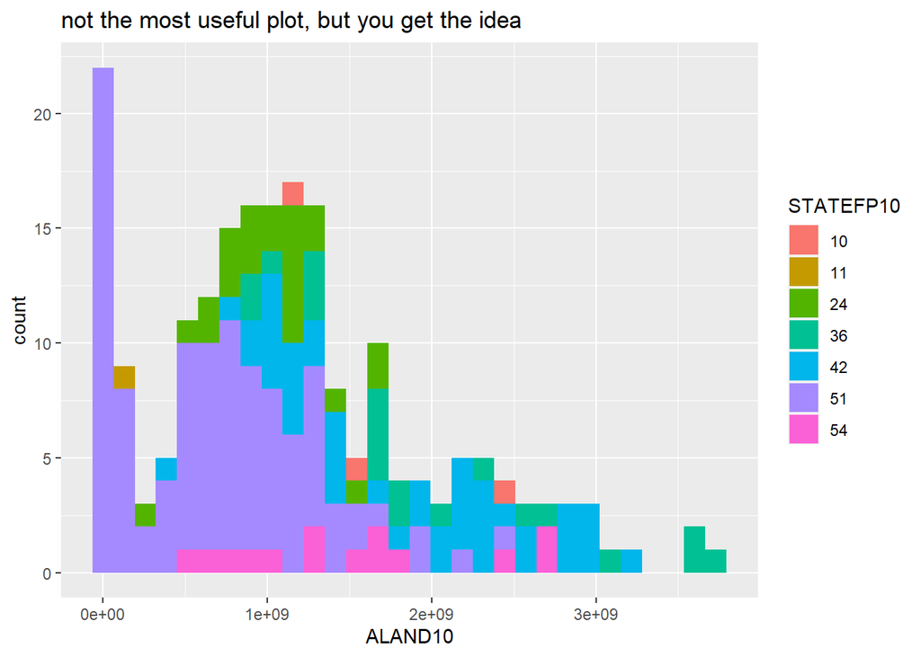

```r
d.counties %>% ggplot(., aes(x = ALAND10)) + geom_histogram(aes(fill = STATEFP10)) + labs(title = "not the most useful plot, but you get the idea")
```

## CRS

```r
d.counties %>% sf::st_crs()
```

```
## Coordinate Reference System:
##   User input: WGS 84
##   wkt:
## GEOGCRS["WGS 84",
##     DATUM["World Geodetic System 1984",
##         ELLIPSOID["WGS 84",6378137,298.257223563,
##             LENGTHUNIT["metre",1]]],
##     PRIMEM["Greenwich",0,
##         ANGLEUNIT["degree",0.0174532925199433]],
##     CS[ellipsoidal,2],
##         AXIS["latitude",north,
##             ORDER[1],
##             ANGLEUNIT["degree",0.0174532925199433]],
##         AXIS["longitude",east,
##             ORDER[2],
##             ANGLEUNIT["degree",0.0174532925199433]],
##     ID["EPSG",4326]]
```

```r
d.stations %>% sf::st_crs()
```

```
## Coordinate Reference System:
##   User input: WGS 84
##   wkt:
## GEOGCRS["WGS 84",
##     DATUM["World Geodetic System 1984",
##         ELLIPSOID["WGS 84",6378137,298.257223563,
##             LENGTHUNIT["metre",1]]],
##     PRIMEM["Greenwich",0,
##         ANGLEUNIT["degree",0.0174532925199433]],
##     CS[ellipsoidal,2],
##         AXIS["latitude",north,
##             ORDER[1],
##             ANGLEUNIT["degree",0.0174532925199433]],
##         AXIS["longitude",east,
##             ORDER[2],
##             ANGLEUNIT["degree",0.0174532925199433]],
##     ID["EPSG",4326]]
```

```r
d.counties %>% sf::st_crs() == d.stations %>% sf::st_crs()
```

```
## [1] TRUE
```

```r
del.counties <- d.counties %>% dplyr::filter(STATEFP10 == 10)
del.stations <- sf::st_intersection(d.stations, del.counties)
glimpse(del.stations)
```

```
## Rows: 2
## Columns: 32
## $ OBJECTID   <int> 2, 1
## $ MAP_ID     <int> 2, 1
## $ USGS_STATI <int> 1488500, 1487000
## $ STATION_NA <chr> "MARSHYHOPE CREEK NEAR ADAMSVILLE, DE", "NANTICOKE RIVER NE~
## $ MAJOR_WATE <chr> "Eastern Shore", "Eastern Shore"
## $ Drainage_A <dbl> 46.79998, 75.39997
## $ START_DATE <int> 2005, 1998
## $ END_DATE   <int> 2018, 2018
## $ Lat        <dbl> 38.84969, 38.72833
## $ Long       <dbl> -75.67311, -75.56186
## $ STAID      <chr> "01488500", "01487000"
## $ OBJECTID.1 <int> 120, 122
## $ STATEFP10  <chr> "10", "10"
```

[output cut: 19 more lines]

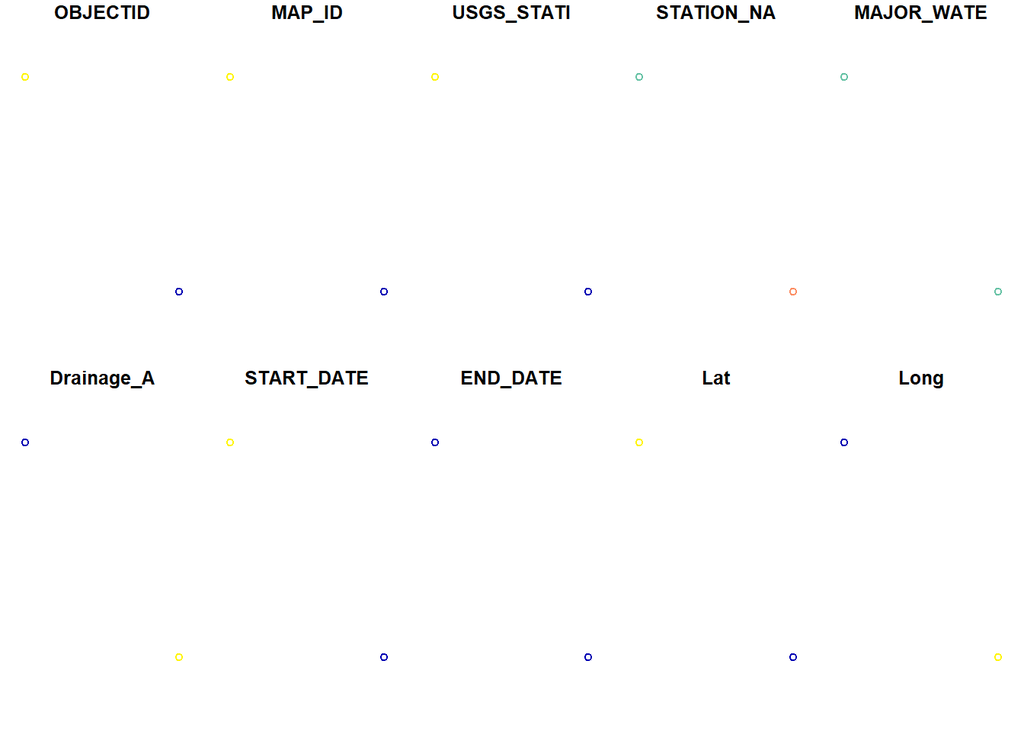

```r
plot(del.stations)
```

```r
del.counties %>% sf::st_area()
```

```
## Units: [m^2]
## [1] 2065913935 3096294979 1278231426
```

## Tasks

### Task 1: Bacis Data Manipulation

#### 1.1 For each county, calculate its land area as percentage of the total area (land + water) for that state.

```r
perland <- d.counties %>% as_tibble() %>% dplyr::select(-geometry) %>% mutate(Landperc = ALAND10/(ALAND10+AWATER10)*100)
perland[, c('NAME10', 'Landperc')]
```

```
## # A tibble: 207 x 2
##    NAME10          Landperc
##    <chr>              <dbl>
##  1 Charlottesville     99.8
##  2 Alexandria          97.2
##  3 Buena Vista         98.7
##  4 Fairfax             99.4
##  5 Cambria             99.2
##  6 Adams               99.4
##  7 Huntingdon          98.4
##  8 Clinton             99.0
##  9 Montour             98.4
## 10 Tioga               99.7
## # ... with 197 more rows
```

#### 1.2 For each state, find the county that has the largest proportion of its land as water (water area / total area)

```r
landaswater <- d.counties %>% as_tibble() %>% dplyr::select(-geometry) %>% group_by(STATEFP10) %>% summarise(county = NAME10, LargestWaterPerc1 = max(ALAND10/(ALAND10+AWATER10)*100))
landaswater
```

```
## # A tibble: 207 x 3
## # Groups:   STATEFP10 [7]
##    STATEFP10 county               LargestWaterPerc1
##    <chr>     <chr>                            <dbl>
##  1 10        Kent                              86.3
##  2 10        Sussex                            86.3
##  3 10        New Castle                        86.3
##  4 11        District of Columbia              89.3
##  5 24        Kent                              99.0
##  6 24        Charles                           99.0
##  7 24        Caroline                          99.0
##  8 24        Allegany                          99.0
##  9 24        Baltimore                         99.0
## 10 24        Frederick                         99.0
## # ... with 197 more rows
```

#### 1.3 Count the number of counties in each state

```r
d.counties %>% group_by(STATEFP10) %>% mutate(count = n())
```

```
## Simple feature collection with 207 features and 21 fields
## Geometry type: MULTIPOLYGON
## Dimension:     XY
## Bounding box:  xmin: -81.01449 ymin: 36.55035 xmax: -74.16468 ymax: 44.09697
## Geodetic CRS:  WGS 84
## # A tibble: 207 x 22
## # Groups:   STATEFP10 [7]
##    OBJECTID STATEFP10 COUNTYFP10 COUNTYNS10 GEOID10 NAME10   NAMELSAD10   LSAD10
##  *    <int> <chr>     <chr>      <chr>      <chr>   <chr>    <chr>        <chr>
##  1        1 51        540        01789068   51540   Charlot~ Charlottesv~ 25
##  2        2 51        510        01498415   51510   Alexand~ Alexandria ~ 25
##  3        3 51        530        01498417   51530   Buena V~ Buena Vista~ 25
##  4        4 51        600        01789070   51600   Fairfax  Fairfax city 25
##  5        5 42        021        01213662   42021   Cambria  Cambria Cou~ 06
##  6        6 42        001        01213656   42001   Adams    Adams County 06
##  7        7 42        061        01213672   42061   Hunting~ Huntingdon ~ 06
##  8        8 42        035        01214721   42035   Clinton  Clinton Cou~ 06
##  9        9 42        093        01213681   42093   Montour  Montour Cou~ 06
## 10       10 42        117        01209189   42117   Tioga    Tioga County 06
## # ... with 197 more rows, and 14 more variables: CLASSFP10 <chr>,
## #   MTFCC10 <chr>, CSAFP10 <chr>, CBSAFP10 <chr>, METDIVFP10 <chr>,
## #   FUNCSTAT10 <chr>, ALAND10 <dbl>, AWATER10 <dbl>, INTPTLAT10 <chr>,
## #   INTPTLON10 <chr>, Shape_Leng <dbl>, Shape_Area <dbl>,
## #   geometry <MULTIPOLYGON [°]>, count <int>
```

```r
d.counties %>% as_tibble() %>% dplyr::select(-geometry) %>% group_by(STATEFP10) %>% summarise(count = n())
```

```
## # A tibble: 7 x 2
##   STATEFP10 count
##   <chr>     <int>
## 1 10            3
## 2 11            1
## 3 24           24
## 4 36           20
## 5 42           43
## 6 51          102
## 7 54           14
```

#### 1.4 Which station has the shortest name (STATION_NA) in the study area?

```r
shortChar <- aggregate(d.stations$STATION_NA, list(d.stations$STATION_NA),
    function(s) min(nchar(as.character(s))))
head(shortChar, 1)
```

```
##                      Group.1  x
## 1 ABRAM CREEK AT OAKMONT, WV 26
```

### Task 2: Plotting attribute data

#### 2.1 Make a scatterplot showing the relationship between land area and water area for each county. Color each point using the state variable

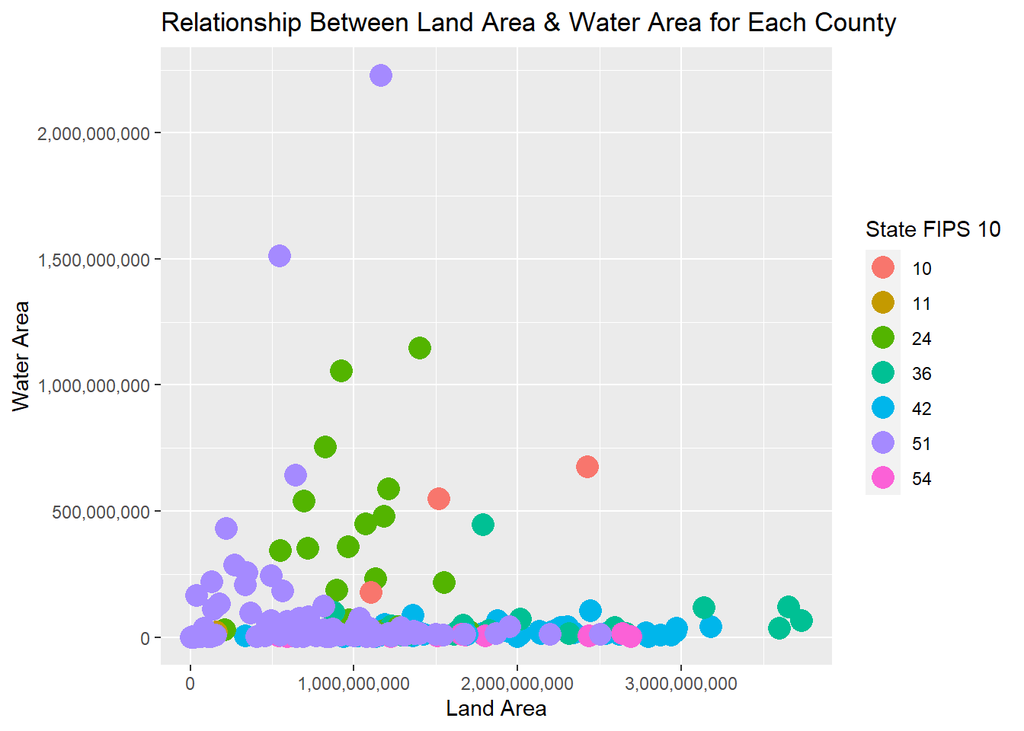

```r
require(scales)
p1 <- ggplot(d.counties, aes(x=ALAND10, y=AWATER10, color=STATEFP10)) +
    geom_point(size=5) + labs(x= "Land Area",
                              y="Water Area",
                              title = "Relationship Between Land Area & Water Area for Each County",
                              colour="State FIPS 10")
    p1 + scale_x_continuous(labels = comma) + scale_y_continuous(labels = comma)
```

#### 2.2 Make a histogram of drainage area (Drainage_A) for all monitoring stations

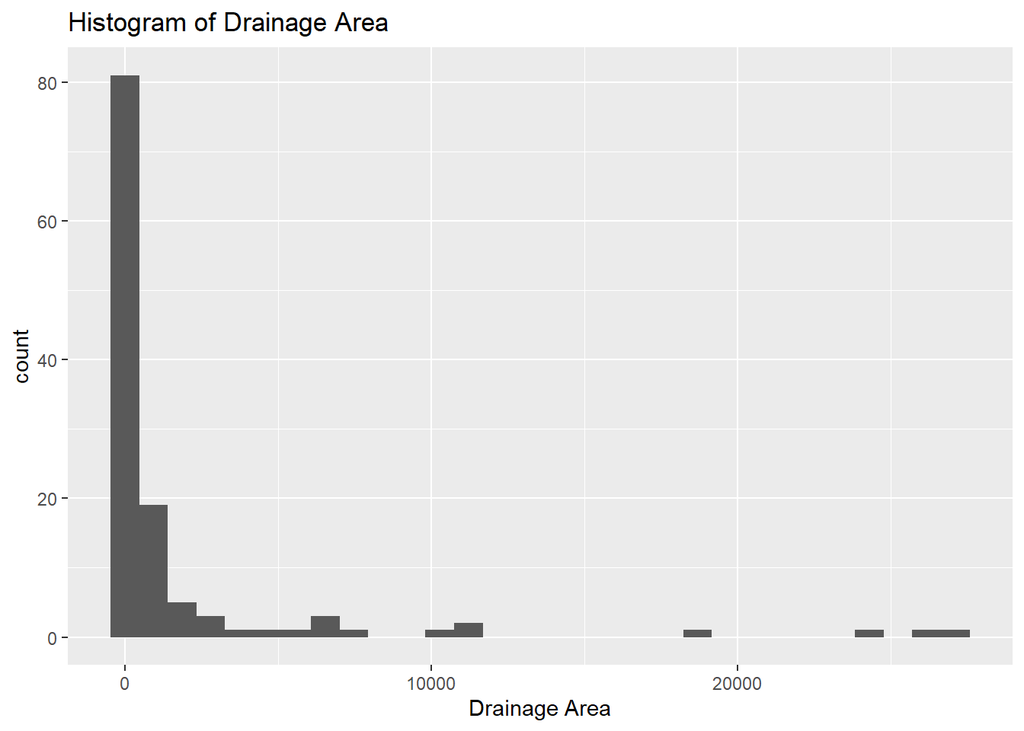

```r
p2 <- ggplot(d.stations, aes(x=Drainage_A)) +
    geom_histogram() + labs(x= "Drainage Area", title = "Histogram of Drainage Area")
p2
```

#### 2.3 Make a similar histogram, this time of drainage area (Drainage_A) for all monitoring stations. Color each point using the state variable

```r
x <- d.stations$STATION_NA
substrRight <- function(x, n){
  substr(x, nchar(x)-n+1, nchar(x))
}
x1 <- d.stations %>% mutate(station_State = substrRight(x, 2))
x1 %>% as_tibble() %>% dplyr::select(-geometry) %>% group_by(station_State)
```

```
## # A tibble: 122 x 12
## # Groups:   station_State [8]
##    OBJECTID MAP_ID USGS_STATI STATION_NA        MAJOR_WATE Drainage_A START_DATE
##       <int>  <int>      <int> <chr>             <chr>           <dbl>      <int>
##  1        1      1    1487000 NANTICOKE RIVER ~ Eastern S~       75.4       1998
##  2        2      2    1488500 MARSHYHOPE CREEK~ Eastern S~       46.8       2005
##  3        3      3    1491000 CHOPTANK RIVER N~ Eastern S~      113.        1985
##  4        4      4    1491500 TUCKAHOE CREEK N~ Eastern S~       85.2       2005
##  5        5      5    1495000 BIG ELK CREEK AT~ Eastern S~       51.6       2005
##  6        6      6    1502500 UNADILLA RIVER A~ Susquehan~      520.        2005
##  7        7      7    1503000 SUSQUEHANNA RIVE~ Susquehan~     2232.        2006
##  8        8      8    1515000 SUSQUEHANNA RIVE~ Susquehan~     4773.        2005
##  9        9      9    1529500 COHOCTON RIVER N~ Susquehan~      470.        2006
## 10       10     10    1531000 CHEMUNG RIVER AT~ Susquehan~     2506.        2005
## # ... with 112 more rows, and 5 more variables: END_DATE <int>, Lat <dbl>,
## #   Long <dbl>, STAID <chr>, station_State <chr>
```

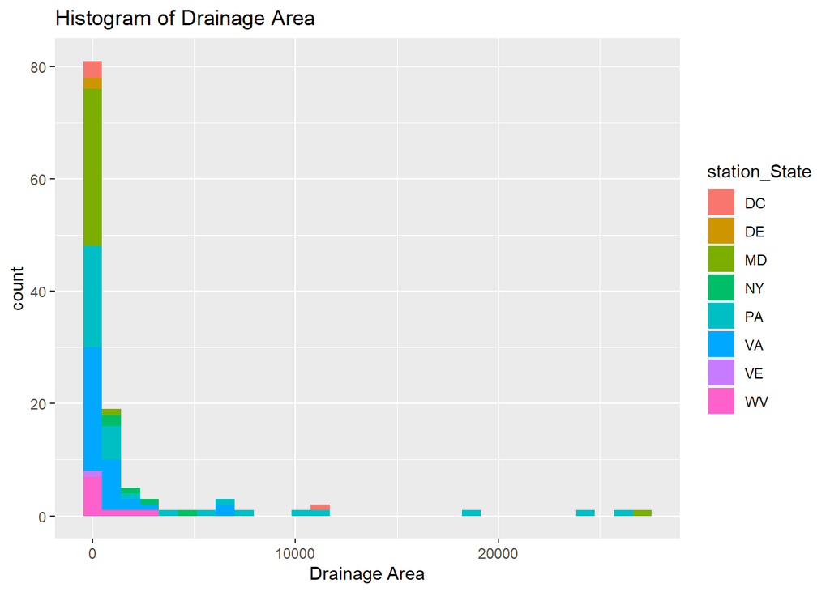

```r
p3 <- ggplot(x1, aes(x=Drainage_A, fill=station_State)) +
    geom_histogram() + labs(x= "Drainage Area", title = "Histogram of Drainage Area")
p3
```

### Task 3: Write a function

#### 3.1 Write a function that does the following:

##### Test it with the following vectors

##### c(1, 0, -1), c(10, 100, 1000), c(.1, .001, 1e8), c(“a”, “b”, “c”)

```r
task3 <- function(...){
  if (is.numeric(...)){
  list <- c(...)
  mean <- mean(list)
  med <- median(list)
  max <- max(list)
  min <- min(list)
  results <- c(mean, med, max, min)
  sort_list <- sort(list)
  cat("List:", sort_list, '\n')
  return(cat('Mean / Med / Max / Min:',results, '\n'))
  } else {
    print("Error: Please insert numeric values")
  }
}

task3(c(1, 0, -1))
```

```
## List: -1 0 1
## Mean / Med / Max / Min: 0 0 1 -1
```

```r
task3(c(10, 100, 1000))
```

```
## List: 10 100 1000
## Mean / Med / Max / Min: 370 100 1000 10
```

```r
task3(c(.1, .001, 1e8))
```

```
## List: 0.001 0.1 1e+08
## Mean / Med / Max / Min: 33333333 0.1 1e+08 0.001
```

```r
task3(c("a", "b", "c"))
```

```
## [1] "Error: Please insert numeric values"
```

### Task 4: (slightly) more complex spatial analysis.

#### 4.1 Calculate the number of monitoring stations in each state

```r
sf::sf_use_s2(F)
```

```
## Spherical geometry (s2) switched off
```

```r
all.stations <- sf::st_intersection(d.stations, d.counties)
all.stations %>% group_by(STATEFP10) %>% mutate(count = n())
```

```
## Simple feature collection with 122 features and 32 fields
## Geometry type: POINT
## Dimension:     XY
## Bounding box:  xmin: -79.897 ymin: 37.22516 xmax: -75.40611 ymax: 42.37779
## Geodetic CRS:  WGS 84
## # A tibble: 122 x 33
## # Groups:   STATEFP10 [7]
##    OBJECTID MAP_ID USGS_STATI STATION_NA        MAJOR_WATE Drainage_A START_DATE
##  *    <int>  <int>      <int> <chr>             <chr>           <dbl>      <int>
##  1      118    120    1558000 LITTLE JUNIATA R~ Susquehan~      220         2012
##  2       13     13    1540500 SUSQUEHANNA RIVE~ Susquehan~    11220.        1985
##  3       91     92    1553700 CHILLISQUAQUE CR~ Susquehan~       51.3       2013
##  4       18     18    1562000 RAYSTOWN BRANCH ~ Susquehan~      756.        2005
##  5       82     82    1534000 TUNKHANNOCK CREE~ Susquehan~      383         2009
##  6       24     24    1574000 WEST CONEWAGO CR~ Susquehan~      510.        2005
##  7       98     99    1575585 CODORUS CREEK NE~ Susquehan~      267.        2013
##  8      101    102    1577500 MUDDY CREEK AT C~ Susquehan~      133.        2015
##  9       19     19    1567000 JUNIATA RIVER AT~ Susquehan~     3354.        1985
## 10       20     20    1568000 SHERMAN CREEK AT~ Susquehan~      207.        2005
## # ... with 112 more rows, and 26 more variables: END_DATE <int>, Lat <dbl>,
## #   Long <dbl>, STAID <chr>, OBJECTID.1 <int>, STATEFP10 <chr>,
## #   COUNTYFP10 <chr>, COUNTYNS10 <chr>, GEOID10 <chr>, NAME10 <chr>,
## #   NAMELSAD10 <chr>, LSAD10 <chr>, CLASSFP10 <chr>, MTFCC10 <chr>,
## #   CSAFP10 <chr>, CBSAFP10 <chr>, METDIVFP10 <chr>, FUNCSTAT10 <chr>,
## #   ALAND10 <dbl>, AWATER10 <dbl>, INTPTLAT10 <chr>, INTPTLON10 <chr>,
## #   Shape_Leng <dbl>, Shape_Area <dbl>, geometry <POINT [°]>, count <int>
```

```r
all.stations %>% as_tibble() %>% dplyr::select(-geometry) %>% group_by(STATEFP10) %>% summarise(count = n())
```

```
## # A tibble: 7 x 2
##   STATEFP10 count
##   <chr>     <int>
## 1 10            2
## 2 11            3
## 3 24           31
## 4 36            4
## 5 42           35
## 6 51           37
## 7 54           10
```

#### 4.2 Calculate the average size of counties in New York (that are also in this study area)

```r
x <- all.stations$STATION_NA
substrRight <- function(x, n){
  substr(x, nchar(x)-n+1, nchar(x))
}
all.stations <- all.stations %>% mutate(station_State = substrRight(x, 2))
ny.counties <- all.stations %>% dplyr::filter(station_State == 'NY')
ny.counties %>% as_tibble() %>% dplyr::select(-geometry) %>% group_by(station_State) %>% summarise(avg_size_NY = mean(ALAND10))
```

```
## # A tibble: 1 x 2
##   station_State avg_size_NY
##   <chr>               <dbl>
## 1 NY            2354104340.
```

#### 4.3 Calculate which state has monitoring stations with the greatest average drainage area (Drainage_A)

```r
meanDrainage <- all.stations %>% as_tibble() %>% dplyr::select(-geometry) %>% group_by(station_State) %>% summarise(avg_drainage = mean(Drainage_A))
s.meanDrainage <- arrange(meanDrainage, desc(avg_drainage))
head(s.meanDrainage, 1)
```

```
## # A tibble: 1 x 2
##   station_State avg_drainage
##   <chr>                <dbl>
## 1 PA                   3549.
```

## Questions

### 1. In using the intersection functions, are the following two statements equivalent? If not, explain how.

#### Be sure to think about BOTH the spatial data structures AND the attribute data. Would your answer be different if we were using different types of data?

##### sf::st_intersection(d.stations, del.counties)

##### sf::st_intersection(del.counties, d.stations)

I think the statements are equivalent. When I checked attribute data for both orders, I found that objects and variables in the attribute data were the same. The only difference was that the attribute data showed the variables in the first input (x) first and then the second input (y).  
In addition, I found this information on the web.  
Introduction to Spatial Data Programming with R - Michael Dorman  
(https://geobgu.xyz/r/geometric-operations-with-vector-layers.html#introduction-5)  
- The order of two inputs does not matter because st_intersection returns all intersections of the geometries from x,y inputs.(symmetrical)  
However, according to the help function of st_intersection, the returned object will have the same class as of the first argument. Therefore, if x, y have different classes, the output class will be depends on the first argument.

### 2. What did you find challenging in this lab? What was new?

Task 1.4  
- At first, I was trying the code “d.stations %>% mutate(length = min(nchar(STATION_NA)))”. However, the output shows that the minimum character count was applied to all counties. So, I used aggregate, which find minimum character from the list.  
Task 3  
- It was challenging because I needed to put “multiple functions” and “if statements” all together in one function.  
Task 4.1  
- I was unable to use st_intersection because of one geometry in the data. However, I found this code “sf::sf_use_s2(FALSE)” from the web, and the problem was solved. This sf_use_s2 was new to me, but I found the additional information about sf_use_s2  
Switching between S2 and GEOS - Edzer Pebesma and Dewey Dunnington  
https://cran.r-project.org/web/packages/sf/vignettes/sf7.html  
sf_use_s2(FALSE) can switch between s2Geometry and GEOS - Geometry Engine, Open Source which “The two-dimensional R2 library that was formerly used by sf.” “GEOS treats projected coordinates as planar (i.e. two points lie on a line of infinite max lenght) while s2 is the two points lie on a great circle of circumference of 40 075 kilometers).”

### 3. What types of activities would you like to see in labs this semester?

I would like to do more labs creating animated plot maps with gganimate because animated map can show series of data in easier and more natural way to the users. Also, I think R can create animated map quicker and easier than other programming languages.